# Bivariate statistical analysis of relevant variables

#### Success Rate / attacktype1_txt

First we want to make an analysis and detect if there is a dependence between the variables attacktype1_txt and success. In order to do that, we make a table with the values of these two variables.

```
                                    FALSE TRUE SuccessRate
Armed Assault                          17  255   0.9375000
Assassination                          52   79   0.6030534
Bombing/Explosion                     307 1034   0.7710664
Facility/Infrastructure Attack         89  764   0.8956624
Hijacking                               2   13   0.8666667
Hostage Taking (Barricade Incident)     3   47   0.9400000
Hostage Taking (Kidnapping)             0   19   1.0000000
Unarmed Assault                        26   31   0.5438596
```

And then we do the chi-square test, in order to check if there is a dependency between these two variables or not.

```
    Pearson's Chi-squared test

data:  aux
X-squared = 159.95, df = 7, p-value < 2.2e-16
```

With a p-value of 2.2e-16, we can reject this test’s null hypothesis and conclude that this variables are, in fact, dependent.

Now we want to analyze the number of successful acts of each type of attack, using a grafical representation.

[interactive chart not shown]

#### Success Rate / weaptype1_txt

First we want to analyze if there is a dependence between the variables weaptype1_txt and success. In order to do that we make a table with the values of these two variables.

```
                   FALSE TRUE SuccessRate
Biological            11   12   0.5217391
Chemical               4   16   0.8000000
Explosives           314 1031   0.7665428
Fake Weapons           2    2   0.5000000
Firearms              45  345   0.8846154
Incendiary            94  740   0.8872902
Melee                  2   41   0.9534884
Other                 14    2   0.1250000
Radiological           1    0   0.0000000
Sabotage Equipment     1   16   0.9411765
Vehicle                0    8   1.0000000
```

And then we do the chi-square test, to check if there is a dependency between this two variables or not.

```
    Pearson's Chi-squared test

data:  aux
X-squared = 144.47, df = 10, p-value < 2.2e-16
```

With a p-value of 2.2e-16, we can reject this test’s null hypothesis and conclude that this variables are, in fact, dependent.

Now we want to analyze with grafical representation the number of successful acts of each weapon type.

[interactive chart not shown]

#### targtype1_txt / provstate

In this section we want to see if there is a relation between the different type of targets and the state where the attacks take place in.

```
    Pearson's Chi-squared test

data:  aux
X-squared = 2288.1, df = 1040, p-value < 2.2e-16
```

With a p-value of 2.2e-16 we can reject this test’s null hypothesis and conclude that this variables are, in fact, dependent.

So with the next table we can see that some big states as California, New York, Florida or Illinois and Puerto Rico have more variability in the type of targets.

```r
aux2 = table(mydata$targtype1_txt,mydata$provstate);
aux2
```

```
                                 Alabama Alaska Arizona Arkansas
  Abortion Related                     3      0       4        0
  Airports & Aircraft                  0      0       0        0
  Business                             2      0       5        3
  Educational Institution              1      0       2        0
  Food or Water Supply                 0      0       0        0
  Government (Diplomatic)              0      0       1        0
  Government (General)                 2      0       5        0
  Journalists & Media                  0      0       1        0
  Maritime                             0      0       0        0
  Military                             1      0       1        0
  NGO                                  1      0       0        0
  Other                                0      0       0        0
  Police                               0      0       0        1
  Private Citizens & Property          4      0       9        0
  Religious Figures/Institutions       2      0       2        0
  Telecommunication                    0      0       0        0
  Terrorists/Non-State Militia         0      0       0        0
  Tourists                             0      0       0        0
  Transportation                       0      0       1        0
  Utilities                            0      1       3        1
  Violent Political Party              0      0       0        0

                                 California Colorado Connecticut Delaware
  Abortion Related                       31        4           0        1
  Airports & Aircraft                     6        0           0        0
  Business                              173        4           5        0
  Educational Institution                55        4           2        0
  Food or Water Supply                    0        0           0        0
  Government (Diplomatic)                19        0           0        0
  Government (General)                   70        7           1        0
  Journalists & Media                    14        1           0        0
  Maritime                                0        0           0        0
  Military                               31        4           2        0
  NGO                                     5        1           1        1
  Other                                   0        0           0        0
  Police                                 38        6           0        0
  Private Citizens & Property            76       12           2        0
  Religious Figures/Institutions         17        1           3        0
  Telecommunication                       1        0           0        0
```

[output cut: 289 more lines]

```
  Government (General)                   3       1
  Journalists & Media                    1       0
  Maritime                               0       0
  Military                               7       0
  NGO                                    0       0
  Other                                  0       0
  Police                                 2       0
  Private Citizens & Property            1       0
  Religious Figures/Institutions         2       0
  Telecommunication                      1       0
  Terrorists/Non-State Militia           0       0
  Tourists                               0       0
  Transportation                         0       0
  Utilities                              3       0
  Violent Political Party                0       0
```

And with this pie chart we can see that the most popular/common target types are:

Business - individuals or organizations engaged in commercial or mercantile activity as a means of livelihood.

Private Citizens & Property - includes attacks on individuals, the public in general or attacks in public areas including markets, commercial streets, busy intersections and pedestrian malls.

Government (General) - any attack on a government building; government member, former members, including members of political parties in official capacities, their convoys, or events sponsored by political parties; political movements; or a government sponsored institution where the attack is expressly carried out to harm the government.

[interactive chart not shown]

#### Success Rate / targtype1_txt

Here we want to study if there is a relation between targtype1_txt and success. For this we make chisq.test() with the next results:

```
    Pearson's Chi-squared test

data:  aux
X-squared = 56.208, df = 20, p-value = 2.704e-05
```

With a p-value of 2.704e-05 we can reject this test’s null hypothesis and conclude that this variables are, in fact, dependent.

And with this table we can see the success rate of each target types implicated in attacks.

```
                               FALSE TRUE SuccessRate
Abortion Related                  38  214   0.8492063
Airports & Aircraft               11   39   0.7800000
Business                         117  640   0.8454425
Educational Institution           38  130   0.7738095
Food or Water Supply               1    3   0.7500000
Government (Diplomatic)           32  112   0.7777778
Government (General)              87  230   0.7255521
Journalists & Media               11   45   0.8035714
Maritime                           0    7   1.0000000
Military                          39  142   0.7845304
NGO                                5   22   0.8148148
Other                              0    2   1.0000000
Police                            29  135   0.8231707
Private Citizens & Property       52  276   0.8414634
Religious Figures/Institutions    14  132   0.9041096
Telecommunication                  5    5   0.5000000
Terrorists/Non-State Militia       1    7   0.8750000
Tourists                           0    9   1.0000000
Transportation                     6   11   0.6470588
Utilities                         10   75   0.8823529
Violent Political Party            0    6   1.0000000
```

#### nperpcap / claimmode_txt

We think it might be interesting to know whether the way in which the perpretators claimed the attack affects or helps capturing them. To analyse it we use the next table, which contains the times each number of perpetrators where captured depending on that variable.

```
                               0  1 2 3 4 5 6 7 8 10 11
Call (post-incident)           0  3 2 2 0 0 0 0 0  0  0
Call (pre-incident)            2  5 0 0 0 0 0 0 0  0  0
E-mail                         6  0 1 1 0 0 0 0 0  0  0
Letter                        17 22 3 4 8 4 0 0 0  0  0
Note left at scene            22 15 1 3 2 0 0 0 0  0  0
Other                          2 11 1 1 1 0 0 0 0  0  0
Personal claim                15 82 4 2 1 0 0 0 0  0  1
Posted to website, blog, etc. 10  5 1 1 0 1 0 0 0  0  0
Video                          2  0 0 0 0 0 0 0 0  0  0
```

We will also represent this with a boxplot to ease the visualization.

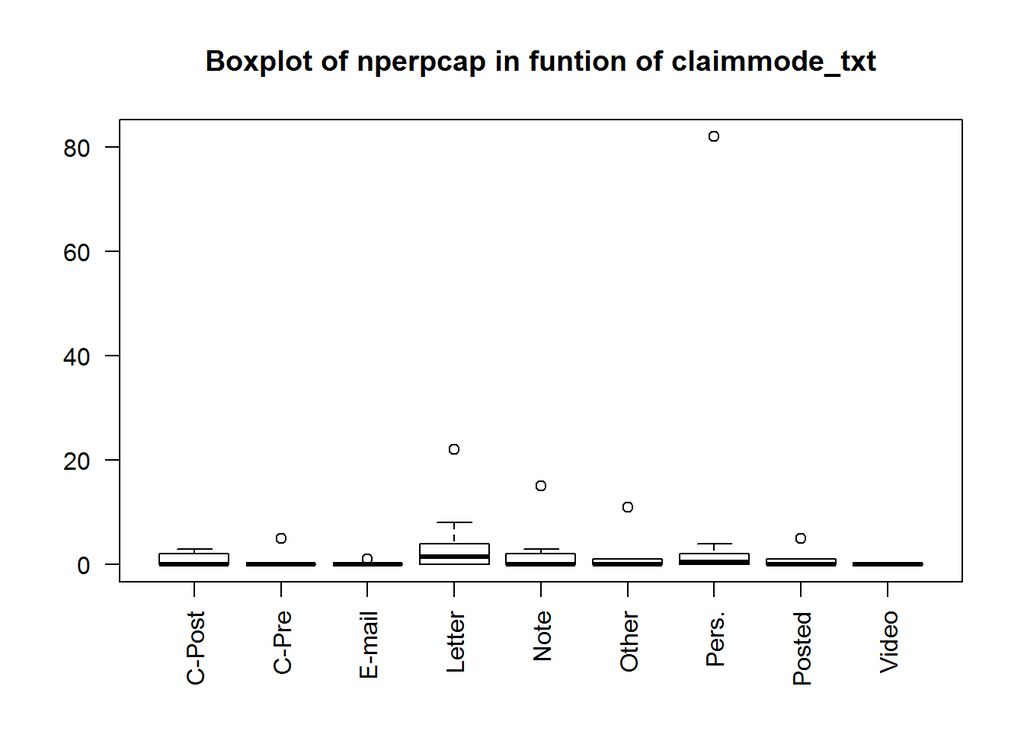

Legend: “C-Post: Call (post-incident)”, “C-Pre: Call (pre-incident)”, “E-mail: E-mail”, “Letter: Letter”, “Note: Note left at scene”, “Other: Other”, “Pers.: Personal claim”, “Posted: Posted to website, blog, etc.”, “Video: Video”

With this boxplot we can obviously see that “Personal claim” has the biggest number of perpetrators captured. We don’t consider it an outlier, but we want to see how the boxplot will change if we delete this particular case. So in the next boxplot we decide to ignore this specific claimed mode.

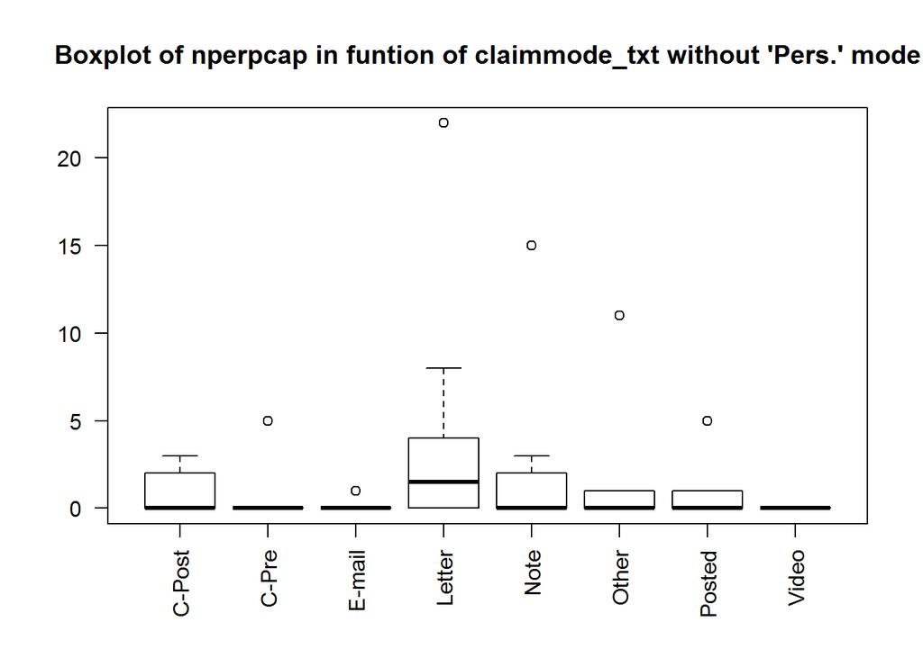

Legend: “C-Post: Call (post-incident)”, “C-Pre: Call (pre-incident)”, “E-mail: E-mail”, “Letter: Letter”, “Note: Note left at scene”, “Other: Other”, “Posted: Posted to website, blog, etc.”, “Video: Video”

And we can see that “Letter” and “Note left at scene” are the next two claimed modes with the biggest number of captured perpetrators.

#### nkill / weaptype1_txt

In this section we study if there is a dependence between the weapon type and number of kills. First of all we make a table with the corresponding variables and see what our data looks like.

```
                        0    1    2    3    4    5    6    7    8    9
  Biological           18    3    2    0    0    0    0    0    0    0
  Chemical             20    0    0    0    0    0    0    0    0    0
  Explosives         1301   35    5    1    1    0    0    0    0    0
  Fake Weapons          4    0    0    0    0    0    0    0    0    0
  Firearms            203  128   35    6    4    3    2    2    2    1
  Incendiary          826    5    2    0    0    0    0    0    0    0
  Melee                29   12    1    1    0    0    0    0    0    0
  Other                16    0    0    0    0    0    0    0    0    0
  Radiological          1    0    0    0    0    0    0    0    0    0
  Sabotage Equipment   16    1    0    0    0    0    0    0    0    0
  Vehicle               3    2    1    0    0    0    0    0    0    0

                       10   11   13   15   16   44   50  190
  Biological            0    0    0    0    0    0    0    0
  Chemical              0    0    0    0    0    0    0    0
  Explosives            0    1    0    0    1    0    0    0
  Fake Weapons          0    0    0    0    0    0    0    0
  Firearms              1    0    1    1    0    0    1    0
  Incendiary            0    0    0    1    0    0    0    0
  Melee                 0    0    0    0    0    0    0    0
  Other                 0    0    0    0    0    0    0    0
  Radiological          0    0    0    0    0    0    0    0
  Sabotage Equipment    0    0    0    0    0    0    0    0
  Vehicle               0    0    0    0    0    1    0    1
```

With this table we understand that there are some columns that have no sense for the study we want to do, so we decide remove them and prepare our data for boxplot.

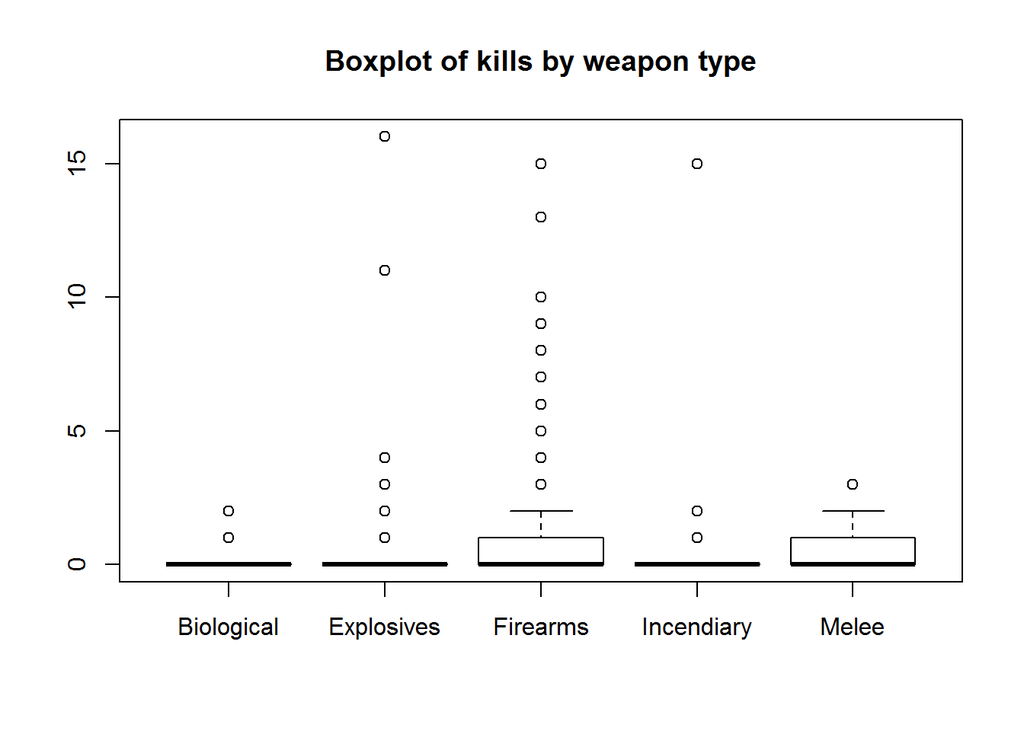

The vast majority of the cases have 0 kills so the graphical representation does not give us much information.

#### nwound / weaptype1_txt

The same type of study as in the “nkill / weaptype1_txt” section: we repeat it with “nwound / weaptype1_txt”.

```
                        0    1    2    3    4    5    6    7    8    9
  Biological           13    3    2    0    0    1    2    0    0    0
  Chemical             15    1    0    2    0    0    0    0    0    0
  Explosives         1205   71   23   11    9    2    1    4    2    0
  Fake Weapons          4    0    0    0    0    0    0    0    0    0
  Firearms            266   60   23   11    8    4    4    2    2    4
  Incendiary          796   22   10    1    0    1    0    0    1    0
  Melee                16   17    1    5    2    1    0    0    0    0
  Other                15    1    0    0    0    0    0    0    0    0
  Radiological          1    0    0    0    0    0    0    0    0    0
  Sabotage Equipment   16    0    0    0    0    0    0    0    0    0
  Vehicle               3    0    0    0    0    0    1    0    0    1

                       10   11   12   13   15   16   17   19   20   22
  Biological            0    0    0    0    0    0    0    0    0    0
  Chemical              1    0    0    0    0    0    0    0    0    0
  Explosives            3    1    0    1    1    1    2    0    1    1
  Fake Weapons          0    0    0    0    0    0    0    0    0    0
  Firearms              1    0    0    1    0    0    0    0    1    0
  Incendiary            0    0    1    0    0    0    0    0    0    0
  Melee                 1    0    0    0    0    0    0    0    0    0
  Other                 0    0    0    0    0    0    0    0    0    0
  Radiological          0    0    0    0    0    0    0    0    0    0
  Sabotage Equipment    0    0    0    0    0    0    0    0    0    0
  Vehicle               0    0    0    0    1    0    0    1    0    0

                       24   25   27   29   32   53   74   78  106  110
  Biological            0    1    0    0    0    0    0    0    0    0
  Chemical              0    0    0    0    1    0    0    0    0    0
  Explosives            0    0    0    1    0    1    1    0    0    1
  Fake Weapons          0    0    0    0    0    0    0    0    0    0
  Firearms              1    0    0    0    1    1    0    0    0    0
  Incendiary            0    0    1    0    0    0    0    0    0    0
  Melee                 0    0    0    0    0    0    0    0    0    0
  Other                 0    0    0    0    0    0    0    0    0    0
  Radiological          0    0    0    0    0    0    0    0    0    0
  Sabotage Equipment    0    0    0    0    0    0    0    1    0    0
  Vehicle               0    0    0    0    0    0    0    0    1    0

                      132  151  751
  Biological            0    0    1
  Chemical              0    0    0
  Explosives            2    0    0
  Fake Weapons          0    0    0
  Firearms              0    0    0
  Incendiary            0    1    0
  Melee                 0    0    0
  Other                 0    0    0
  Radiological          0    0    0
  Sabotage Equipment    0    0    0
  Vehicle               0    0    0
```

Most of the weapon types have small quantities of kills which would distort our representation. We will remove those types for the graphical comparison just as we did before.

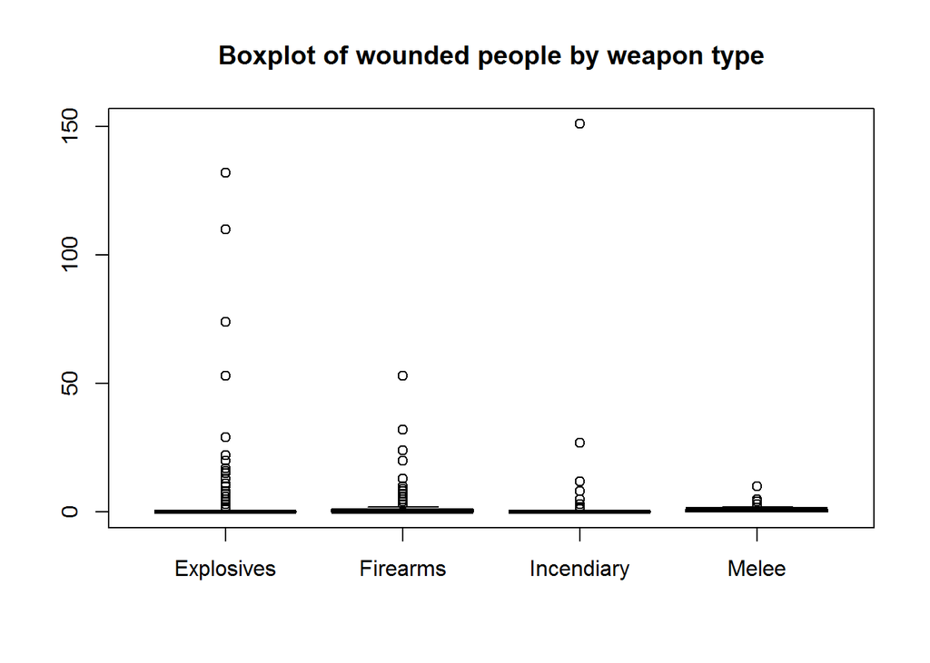

The vast majority of the cases have 0 wounded, so the graphical representation does not give us much information.

#### nº acts / year date

In this analysis, we want to look into the distribution of acts over the years. We will see 10 year intervals and 1970-2017 graphs in order to compare them properly.

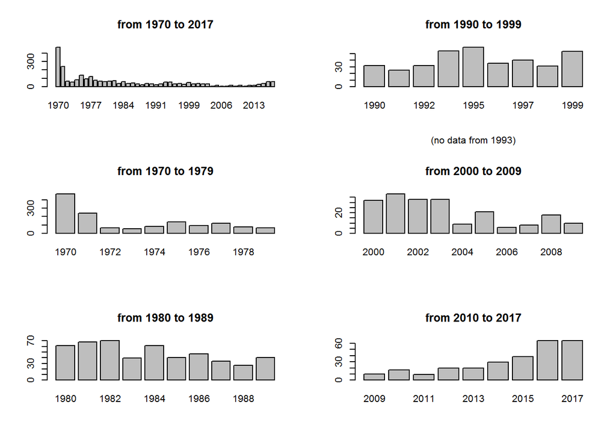

We can see that the year with most acts of terrorism is by far 1970. In the last graph 2009-2017 we can clearly see that there is an increasing tendency.

#### nº acts / month

In this analysis we want to see what is the distribution of acts of terrorism over the months in order to see if there is any anomaly.

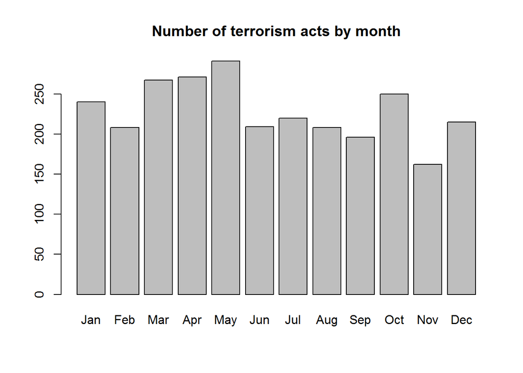

The acts are fairly uniform distributed, with the preferred month being May and the least favorite being November.

#### provstate / gname

This two categorical variable seem interesting to analyze, but first we need to bee sure if there is a relation between them. As we know, for this we can use the chi square test.

```
    Pearson's Chi-squared test

data:  mydata$provstate and mydata$gname
X-squared = 23839, df = 11400, p-value < 2.2e-16
```

With a p-value of 2.2e-16, we can reject this test’s null hypothesis and conclude this variables are, in fact, dependent.

#### gname / provstate (top 3 provstate)

In this analysis, we want to see the distributions of acts of terrorism by each group in the 3 most striked states.

We will remove the gname with less than 9 apperances in order to properly view the result, as we will not consider them relevant to our study.

[interactive chart not shown]

We can see that 25.5% of the acts of terrorism in California are from the same group.

[interactive chart not shown]

Most of the names of this pie chart do not match the ones in the California one. That confirms us that different groups focus different states.

[interactive chart not shown]

By the names of the groups and the quantity of them we can already see that Puerto Rico’s terrorist attacks are majorly internal.

#### provstate / gname (top 3 gname)

In this analysis we want to identify in which states a given gname has committed acts of terrorism. This will provide us insight of the group’s target population.

[interactive chart not shown]

We can see that this group widely distributed their acts of terrorism over the states.

[interactive chart not shown]

We can see that this group’s acts were fairly distributed, although half of them were targeted to the two main victim states.

[interactive chart not shown]

In this case we can clearly see that the acts were targeted towards the states of New York, Illinois and Puerto Rico.

#### Event Rate / state_governor_party (top 3 provstates)

We want to know what is the percentage of acts committed during the rule of each state_governor_party. Only the 3 states with most recorded acts will be considered, because in some of the states the sample size would be too small.

We will remove the minor state_governor_parties with less than 9 apperances in order to properly view the result as we will not consider them relevant to our study.

First, we will check California as it is the first state with most recorded acts of terrorism (532).

[interactive chart not shown]

Not considering the outliers, we can see that 69.9% of the acts were committed in this state while the Democrat party was ruling.

We will do the same analysis with New York as it is the second state with most recorded acts of terrorism (473).

[interactive chart not shown]

In this case the ratio is more equaly distributed, with 51.6% for the Democrats

Lastly we will do the same analysis with Puerto Rico as it is the third state with most recorded acts of terrorism (226).

[interactive chart not shown]

In the pie chart we can see that 65.3% of the acts were commited while the New Progressive Party was ruling.

#### Success Rate / president_party

In this analysis we want to check what is the ratio of success of terrorism acts while each president_party was ruling.

```r
success = mydata$president_party[mydata$success == TRUE]
fail = mydata$president_party[mydata$success == FALSE]
success = as.data.frame(table(success))
fail = as.data.frame(table(fail))
s = success[2]+fail[2]
ts = 100*success[2]/s
tf = 100*fail[2]/s

s=c(ts[1,1],ts[2,1])
f=c(tf[1,1],tf[2,1])
t <- cbind(s,f);
colnames(t) <- c("Success", "Fail")
rownames(t) <- c("Democratic", "Republican")

print(t)
```

```
            Success     Fail
Democratic 79.57245 20.42755
Republican 82.91139 17.08861
```

As we can see, both parties have similar success rates.